# hw8

# ———————————————

# 7.17

## a. Transfonn the variables by means of the correlation transformation (7.44) and fit the standardized regression model (7.45).

```r
x_matirx=cor(grocerry)[2:4,2:4]
y_matrix=cor(grocerry)[1,2:4]

b_matrix=solve(x_matirx,y_matrix)
print(b_matrix)
```

```
##         x1         x2         x3
##  0.1747189 -0.0463913  0.8078617
```

## b. Calculate the coefficients of determination between all pairs of predictor variables. Is it meaningful here to consider the standardized regression coefficients to reflect the effect of one predictor variable when the others are held constant?

```r
##R12
summary(lm(x1~x2,data=grocerry))
```

```
##
## Call:
## lm(formula = x1 ~ x2, data = grocerry)
##
## Residuals:
##    Min     1Q Median     3Q    Max
## -85825 -33900 -14882  22577 165347
##
## Coefficients:
##             Estimate Std. Error t value Pr(>|t|)
## (Intercept)   263272      65884   3.996 0.000212 ***
## x2              5348       8877   0.602 0.549575
## ---
## Signif. codes:  0 '***' 0.001 '**' 0.01 '*' 0.05 '.' 0.1 ' ' 1
##
## Residual standard error: 55620 on 50 degrees of freedom
## Multiple R-squared:  0.007207,   Adjusted R-squared:  -0.01265
## F-statistic: 0.363 on 1 and 50 DF,  p-value: 0.5496
```

```r
##R23
summary(lm(x2~x3,data=grocerry))
```

```
##
## Call:
## lm(formula = x2 ~ x3, data = grocerry)
##
## Residuals:
##      Min       1Q   Median       3Q      Max
## -2.72500 -0.53000 -0.05417  0.60250  2.00667
##
## Coefficients:
##             Estimate Std. Error t value Pr(>|t|)
## (Intercept)   7.3350     0.1298  56.507   <2e-16 ***
## x3            0.3083     0.3821   0.807    0.424
## ---
## Signif. codes:  0 '***' 0.001 '**' 0.01 '*' 0.05 '.' 0.1 ' ' 1
##
## Residual standard error: 0.8804 on 50 degrees of freedom
## Multiple R-squared:  0.01285,    Adjusted R-squared:  -0.00689
## F-statistic: 0.651 on 1 and 50 DF,  p-value: 0.4236
```

```r
##R13
summary(lm(x1~x3,data=grocerry))
```

```
##
## Call:
## lm(formula = x1 ~ x3, data = grocerry)
##
## Residuals:
##    Min     1Q Median     3Q    Max
## -97669 -33031 -10519  16658 170686
##
## Coefficients:
##             Estimate Std. Error t value Pr(>|t|)
## (Intercept)   301790       8222  36.704   <2e-16 ***
## x3              7823      24206   0.323    0.748
## ---
## Signif. codes:  0 '***' 0.001 '**' 0.01 '*' 0.05 '.' 0.1 ' ' 1
##
## Residual standard error: 55770 on 50 degrees of freedom
## Multiple R-squared:  0.002085,   Adjusted R-squared:  -0.01787
## F-statistic: 0.1044 on 1 and 50 DF,  p-value: 0.7479
```

```r
## the co-efficients before standardisation and after standardisation only differ by scale -- hence can be said the same as before

## c. Transform the estimated standardized regression coefficients by means of (7.53) back to the ones for the fitted regression model in the original variables. Verify that they are the same as the ones obtained in Problem 6. lOa.
b_1=(sd(grocerry$y)/sd(grocerry$x1))*b_matrix[1]
b_1
```

```
##           x1
## 0.0007870804
```

```r
b_2=(sd(grocerry$y)/sd(grocerry$x2))*b_matrix[2]
b_2
```

```
##        x2
## -13.16602
```

```r
b_3=(sd(grocerry$y)/sd(grocerry$x3))*b_matrix[3]
b_3
```

```
##       x3
## 623.5545
```

```r
b_0=mean(grocerry$y)-(b_1*mean(grocerry$x1))-(b_2*mean(grocerry$x2))-(b_3*mean(grocerry$x3))
b_0
```

```
##       x1
## 4149.887
```

```r
lm(y~x1+x2+x3,data=grocerry)
```

```
##
## Call:
## lm(formula = y ~ x1 + x2 + x3, data = grocerry)
##
## Coefficients:
## (Intercept)           x1           x2           x3
##   4.150e+03    7.871e-04   -1.317e+01    6.236e+02
```

```r
## they are same
```

# 8.24

## Plot the sample data for the two populations as a symbolic scatter plot. Does the regression relation appear to be the same for the two populations?

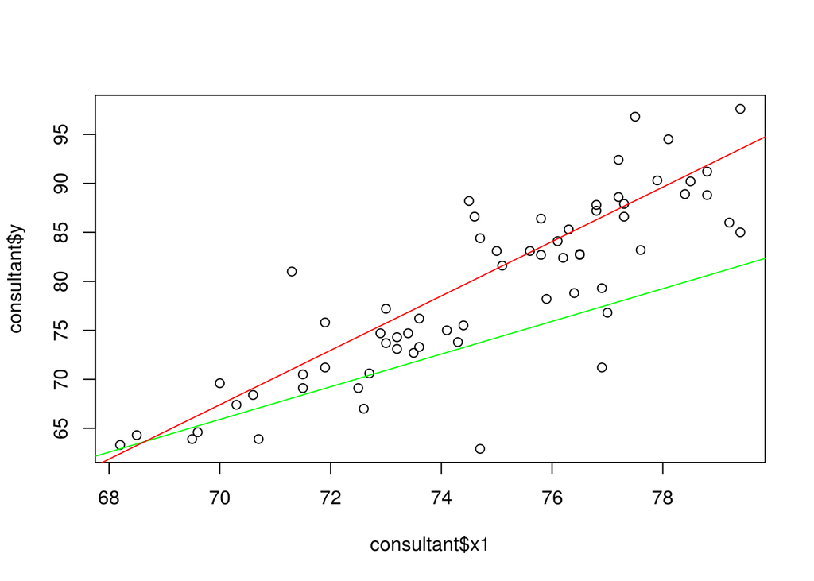

```r
plot(consultant$x1,consultant$y)
abline(lm(y~x1,data=consultant[consultant$x2==1]),col="green")
abline(lm(y~x1,data=consultant[consultant$x2==0]),col="red")
```

```r
## as we can see the regression lines differ,so thr relation is different

## b. Test for identity of the regression functions for dwellings on comer lots and dwellings in other locations; control the risk of Type I error at .05. State the alternatives, decision rule,and conclusion.
```

= 0.05

model y=b_0+b_1 x1+b_2 x2+b3 x_1*x_2

if there is no relation then both b2 and b3 should be zero

so h_0 > b_2 = b_3 =0 h_a > b_2 !=0 and b_3 !=0

F* = MSR(x2,x1x2|x1)/MSR(x1,x2,x1x2) MSR(x2,x1x2|x1) = SSR(x2|x1)+SSR(x1x2|x1,x2)/2 =453.1+113/2 =566.1/2 =283.05

MSR(x1,x2,x1x2) = 909/60=15.2

F*= 283.05/15.2 =18.62 >F(0.95,2,60) = 3.15 So we reject null hypothesis

# Decision

We conclude that there are different and not identical

## c. Plot the estimated regression functions for the two populations and describe the nature of the differences between them.

```r
lm(y~x1,data=consultant[consultant$x2==0])
```

```
##
## Call:
## lm(formula = y ~ x1, data = consultant[consultant$x2 == 0])
##
## Coefficients:
## (Intercept)           x1
##    -126.905        2.776
```

```r
lm(y~x1,data=consultant[consultant$x2==1])
```

```
##
## Call:
## lm(formula = y ~ x1, data = consultant[consultant$x2 == 1])
##
## Coefficients:
## (Intercept)           x1
##     -50.884        1.668
```

```r
## there is difference in both the intercept and slope so wher x2=1 prices increase at a slower pace while x2=0 prices increase at a faster pace
```